# Guildford · where district heating fits

### Spatial opportunity, individual alternatives and whole-system trade-offs

A promising heat-density map is only a starting point. A heat network also needs enough connections, a viable plant, an electrical connection and a fair accounting of its pipes. This notebook follows the most developed saved DH experiment: **candidate zone 4 in Stoughton**, evaluated within **15 complete electricity zones / 2,534 dwellings**.

Three saved cases compare individual heating, DH with a central heat pump, and the additional option of gas CHP. Results date from **6–7 September 2026** and use the earlier EnerMap release. This is a snapshot investment study, not a deployment pathway or construction-ready design. The full-year DH replay has a small residual electricity shortfall; that caveat is part of the result.

| Case | dwellings | objective_mgbp | emissions_kt | dh_dwellings | dh_plant_hp_capacity_mw_th |
| --- | --- | --- | --- | --- | --- |
| A | 2534.0 | 2.984 | 2.199 | 0.0 | 0.000 |
| B | 2534.0 | 3.037 | 1.997 | 831.0 | 4.962 |
| C | 2534.0 | 3.037 | 1.997 | 831.0 | 4.962 |

## 1 · Start with the streets, but do not confuse screening with design

The left panel shows the earlier Guildford street-network screening. “Selected” means selected by that screening calculation—not installed infrastructure or the final zone-4 layout. Geometry is in British National Grid (EPSG:27700). The right panel shows the actual **zone-level DH uptake in case C**, as a share of all dwellings in each electrical zone. The two panels have different scales and purposes.

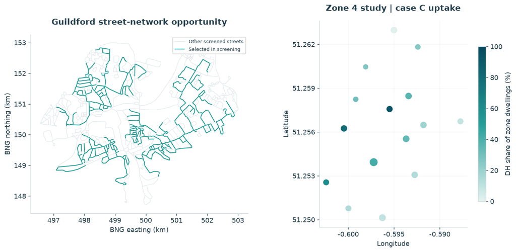

## 2 · Three different populations explain the candidate

The pipe cost curve was derived on an earlier screening basis of **1,420 dwellings**. After the building-to-route distance and EnerMap matching rules, **1,051 dwellings** are eligible to connect. The optimisation includes **2,534 dwellings** because it retains their complete electrical zones and individual heating alternatives. About **831 dwelling equivalents** connect in the selected solution. These numbers are different boundaries—not interchangeable measures of connection rate.

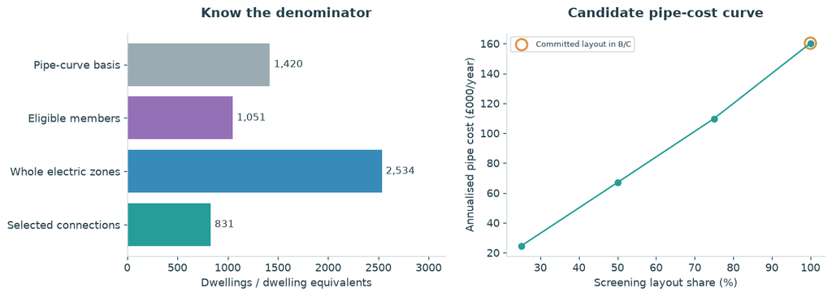

|  | Saved candidate input |
| --- | --- |
| zone | zone_4 |
| peak_mw | 8.053 |
| capex_gbp_per_mw_yr | 19895.176 |
| committed_pipe_cost_gbp_per_yr | 160214.064 |
| loss_share | 0.011 |
| trench_m | 4313.41 |
| connection_bus | gsp |
| connection_capacity_mw | 5.0 |

## 3 · How the spatial work enters PyPSA

Topotherm-derived pipe cost/capacity information enters as a **fixed candidate layout**, with a committed annual pipe cost. PyPSA then chooses connections and plant capacity alongside individual heating. It is not jointly rerouting the streets in this solve.

| Component | Coupling in the saved DH model |
| --- | --- |
| Energy-centre electricity | Dedicated site bus, 5 MW import-only GSP connection |
| Central HP | Electricity-to-heat Link with hourly COP |
| Gas CHP option | Multi-output Link: gas input → electricity + heat |
| Heat distribution | Supply/delivery buses and a lossy, capacity-limited connection |
| Building connections | Eligible cluster options with connection/HIU cost |
| Individual alternatives | Available alongside DH, sharing the local electrical constraints |

The candidate has 4.31 km of trench and an 8.05 MW curve-based heat capacity. Losses are a fixed topotherm-derived share with a ×2 derating assumption, not a full hourly hydraulic calculation. There is no central thermal storage or electricity export in these saved cases; CHP electricity can serve the energy centre only.

## 4 · Count the pipes before comparing costs

**A:** individual heating only. **B:** add DH with a central heat pump. **C:** also allow gas CHP. All share a 2.199 ktCO2 cap; their achieved emissions differ.

The plant/operation subtotal makes DH look cheaper, but the **committed pipe cost must be added back**. With that included, B costs about £53,000/year more than A (+1.77%) while emissions are about 9.17% lower. This is a cost–carbon trade-off under the saved assumptions, not a claim that DH is universally cheaper. Mixed cost years remain a caveat.

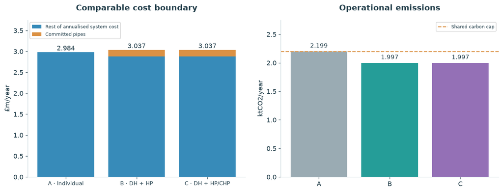

```
B − A annualised cost: £52,958/year
```

## 5 · What gets built in the model?

B and C select nearly identical DH outcomes: approximately **4.96 MWth of central HP** and **831 connections**. Allowing CHP does not mean the optimiser selects it: the saved CHP capacity and output are numerically zero. This finding is conditional on gas/carbon prices, HP performance and the import-only connection restriction. The clean-heat-share field in the source excludes DH by its option flag, so it is not used here as an A/B/C heat-decarbonisation score.

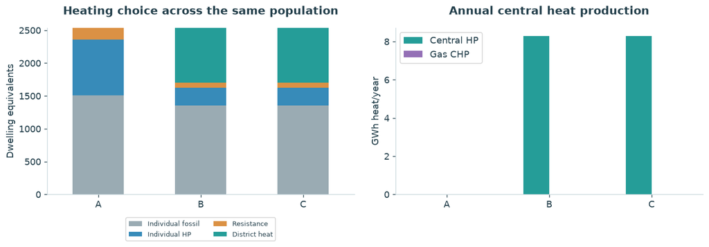

## 6 · Replay the operation across the year

Case C was replayed jointly for all 15 zones. These curves sum the saved option-level heat-delivery schedules at the dwelling-side heating options; they are not fuel input or electricity demand. Central HP production is higher than delivered DH because of the modelled network loss.

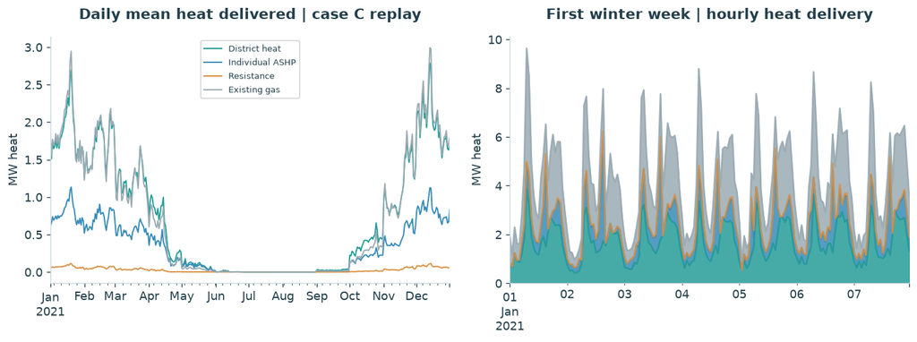

## 7 · The unresolved check belongs on the page

The replay reports **zero unmet heat**, but **73.2 kWh of unmet electricity** over the year. That exceeds the model's 1 kWh feasibility tolerance. It is small in annual energy terms, but the strict feasibility check has **not passed**. The next model iteration should identify the affected hours and bus, repair the constraint/dispatch issue and rerun the replay before this is presented as a feasible design.

There is also a reporting boundary mismatch: the aggregated grid subtotal in the replay report omits central DH electricity, whereas its replay total includes it. The apparent 32% difference must not be presented as a temporal-aggregation error. The original table is retained for audit, not silently repaired.

| metric | replay | unit |
| --- | --- | --- |
| zones | 15.000 | count |
| unmet_heat_mwh | 0.000 | MWh/yr - must be ~0 |
| unmet_elec_mwh | 0.073 | MWh/yr - must be 0 |
| dh_heat_from_hp_mwh | 8181.225 | MWh/yr or ratio (joint DH replay) |
| dh_delivered_mwh | 8088.147 | MWh/yr or ratio (joint DH replay) |
| dh_pipe_peak_utilisation | 0.623 | MWh/yr or ratio (joint DH replay) |

```
UNRESOLVED: 73.2 kWh unmet electricity; permitted tolerance = 1.0 kWh.
Full-year heat coverage does not cancel an electrical feasibility failure.
```

## The next useful experiments

First resolve the hourly electricity shortfall and align grid accounting. Then test connection uptake, retrofit/DH interaction, central storage, alternative site connections, cost-year harmonisation and the latest EnerMap demand. Non-residential anchor loads could materially alter viability, but they are not completed results in this release.